## Executive Summary

The data from mtcars will be analyzed to determine the relationship between the miles per gallon (mpg) and the transmission of the car. We use regression models and exploratory data analyses to identify how automatic (am = 0) and manual (am = 1) transmissions features affect the MPG feature. The t-test shows that there is a performance difference between cars with automatic and manual transmission.

### Data Processing

Load the data from mtcars and changed some variables (cyl, vs, gear, carb, and am) from numeric to factor.

```r
data(mtcars)
mtcars$am = factor(mtcars$am, label = c("Automatic", "Manual"))
mtcars$cyl = as.factor(mtcars$cyl)
mtcars$gear = as.factor(mtcars$gear)
mtcars$car = as.factor(mtcars$carb)
mtcars$vs = as.factor(mtcars$vs)
auto = subset(mtcars, mtcars$am == "Automatic")
manu = subset(mtcars, mtcars$am == "Manual")
```

### Exploratory Analysis

Plots were created to show how the data is distributed amongst transmission and mpg (Appendix, “MPG vs. Transmission”) and scatterplot matrix (Appendix, “Scatterplot Matrix”). There is a clear distinction between automatic transmission and manual transmission vehicle’s MPG. Manual cars have a higher maximum mpg and minimum mpg compared to automatic cars.

### Hypothesis Testing

```r
t.test(manu$mpg, auto$mpg)
```

```
##
##  Welch Two Sample t-test
##
## data:  manu$mpg and auto$mpg
## t = 3.7671, df = 18.332, p-value = 0.001374
## alternative hypothesis: true difference in means is not equal to 0
## 95 percent confidence interval:
##   3.209684 11.280194
## sample estimates:
## mean of x mean of y
##  24.39231  17.14737
```

### Regression Analysis

#### Linear Regression

Where am is the predictor and mpg is the output.

```r
fmodel<-lm(mpg~ am, data=mtcars)
summary(fmodel)
```

[output not shown]

It is observed that the p-value and adjusted R-squared is less than 0.05 which is not of significance.

#### Multivariate Regression

```r
fmodel<-lm(mpg~.,data=mtcars)
bmodel<-step(fmodel,direction='both')
summary(bmodel)
```

### Conclusion

In addition, A 95% T test of the transmission of the cars to mpg shows that their means are significantly different. We therefore conclude that Manual transmission have better MPG compared to Automatic transmission.

### Appendix

1. MPG vs. Transmission

[figure not shown]

```r
boxplot(data = mtcars,
        mpg ~ am,
        xlab = "(am = 0) and manual (am = 1) Transmissions",
        ylab = "miles per gallon",
        main = "Boxplot of MPG vs. Transmission",
        col = "lightgreen")
```

2. Regression Analysis

[output not shown]

[output cut: 72 more lines]

```
## Step:  AIC=61.31
## mpg ~ wt + qsec + am
##
##        Df Sum of Sq    RSS    AIC
## <none>              169.29 61.307
## + hp    1     9.219 160.07 61.515
## + disp  1     3.276 166.01 62.682
## + cyl   1     1.501 167.78 63.022
## + drat  1     1.400 167.89 63.042
## + vs    1     0.000 169.29 63.307
## - am    1    26.178 195.46 63.908
## + gear  2     0.185 169.10 65.272
## + carb  5    10.999 158.29 69.158
## - qsec  1   109.034 278.32 75.217
## - wt    1   183.347 352.63 82.790
```

```
##
## Call:
## lm(formula = mpg ~ wt + qsec + am, data = mtcars)
##
## Residuals:
##     Min      1Q  Median      3Q     Max
## -3.4811 -1.5555 -0.7257  1.4110  4.6610
##
## Coefficients:
##             Estimate Std. Error t value Pr(>|t|)
## (Intercept)   9.6178     6.9596   1.382 0.177915
## wt           -3.9165     0.7112  -5.507 6.95e-06 ***
## qsec          1.2259     0.2887   4.247 0.000216 ***
## amManual      2.9358     1.4109   2.081 0.046716 *
## ---
## Signif. codes:  0 '***' 0.001 '**' 0.01 '*' 0.05 '.' 0.1 ' ' 1
##
## Residual standard error: 2.459 on 28 degrees of freedom
## Multiple R-squared:  0.8497, Adjusted R-squared:  0.8336
## F-statistic: 52.75 on 3 and 28 DF,  p-value: 1.21e-11
```

```
##                   2.5 %    97.5 %
## (Intercept) -4.63829946 23.873860
## wt          -5.37333423 -2.459673
## qsec         0.63457320  1.817199
## amManual     0.04573031  5.825944
```

3. Scatterplot Matrix

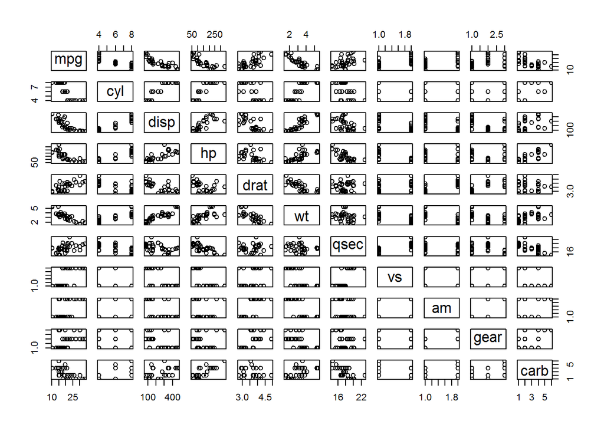

4. Residual Plots of the bmodel

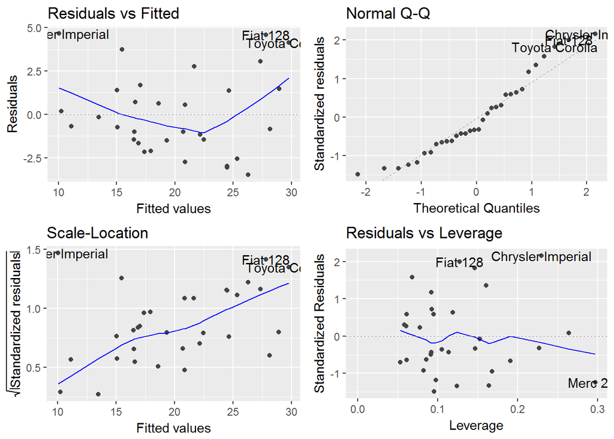